# Database Gestione Esami GAL

Gruppo: Laklaa Marwa(1099064), Frimane Karima (1100141), Derouich Sukaina (1099300)

Giugno 2026

## 1. Introduzione

Il nostro progetto nasce dall’obiettivo di sviluppare una base di dati dedicata alla gestione logistica e burocratica degli appelli d’esame all’interno di un dipartimento universitario. Per dare al lavoro un’impronta il più possibile concreta e applicativa, abbiamo scelto come punto di partenza l’esame di Geometria e Algebra Lineare (GAL) che abbiamo sostenuto lo scorso anno accademico. Conoscendone direttamente le dinamiche, l’elevata affluenza di studenti e la complessità nella gestione dei turni, lo abbiamo ritenuto il caso di studio ideale da analizzare.

Per definire i vincoli di integrità e popolare le tabelle in modo realistico, abbiamo basato la nostra analisi sui dati reali degli esiti e delle aule assegnate per l’esame di GAL, recuperati direttamente dal portale Moodle. L’elaborazione di queste informazioni ci ha permesso di strutturare con precisione logiche organizzative complesse, come la prenotazione delle aule (tenendo conto della capienza massima e dell’idoneità per studenti con certificazione DSA) e la ripartizione dei turni d’aula per fasce alfabetiche.

Un aspetto centrale su cui ci siamo concentrati è stato la modellazione delle valutazioni . Distinguendo concettualmente il singolo compito scritto (la Prova) dal risultato d’esame registrato sul libretto (l’Esito), abbiamo strutturato una soluzione flessibile per gestire gli esami composti da più prove, come i parziali. Questo approccio ci ha consentito di calcolare dinamicamente i voti finali, prevenendo ridondanze nei dati o possibili incongruenze amministrative in fase di verbalizzazione.

### 1.1 Consegna

Si vuole progettare una base di dati per la gestione degli appelli d’esame, della sorveglianza in aula e della verbalizzazione dei voti per un dipartimento universitario.

Degli studenti interessa memorizzare la matricola, che funge da identificatore univoco, il nome, il cognome, l’indirizzo e-mail istituzionale, il corso di laurea di appartenenza, l’anno di immatricolazione, l’eventuale superamento degli OFA (Obblighi Formativi Aggiuntivi) e se si tratta di studenti con certificazione DSA. Gli esami si svolgono in specifiche aule , identificate univocamente da una sigla; di ogni aula si vuole conoscere la capienza massima di posti e se essa sia idonea ad ospitare studenti DSA.

Il dipartimento si avvale di personale interno, il quale si suddivide nelle due categorie distinte dei docenti strutturati e dei collaboratori . Per tutto il personale si memorizzano il codice fiscale, il nome, il cognome, l’indirizzo (composto da via, civico e CAP) e uno o più numeri di telefono . Dei docenti strutturati interessa registrare l’ufficio e il dipartimento di appartenenza. Dei collaboratori interessa invece tracciare l’anno di corso, la tipologia e la scadenza del contratto. Si tenga presente che ogni collaboratore deve essere sempre supervisionato da un docente strutturato che assume il ruolo di suo tutor.

Un appello d’esame è identificato da un codice univoco ed è caratterizzato da una data, un’ora di inizio, un anno accademico e una tipologia (che può assumere esclusivamente i valori: “Primo Parziale”, “Secondo Parziale” o “Esame Totale”).

Al fine di calcolare correttamente le medie senza introdurre ridondanze nei dati, il sistema deve distinguere il conseguimento finale dell’esame dallo svolgimento del singolo compito in aula. Il singolo compito svolto in un turno d’aula prende il nome di prova . Della prova si tracciano la traccia d’esame assegnata (compito), il numero di risposte giuste, errate e omesse, e il voto ottenuto in quella singola prova. Il libretto dello studente per la materia prende invece il nome di esito. Ogni esito è conseguito da un solo studente e si compone di una o più prove (ad esempio, due prove distinte se l’esito finale deriva dalla media delle prove parziali, oppure una sola prova se deriva dall’esame totale). Dell’esito si registrano l’eventuale variazione dovuta a un esame orale, il voto scritto complessivo calcolato, il voto finale verbalizzato e lo stato della verbalizzazione.

## 2. Progetto Concettuale

SCHEMA E-R

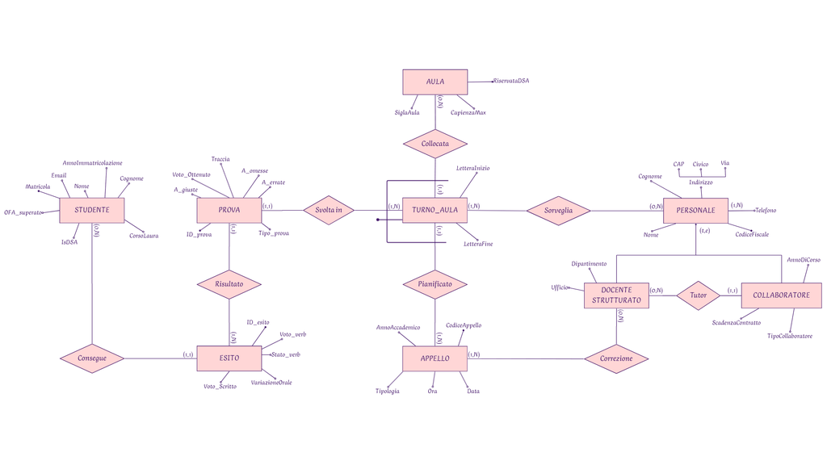

*Clicca sull’immagine per aprirla a schermo intero*

## 3. Progetto Logico

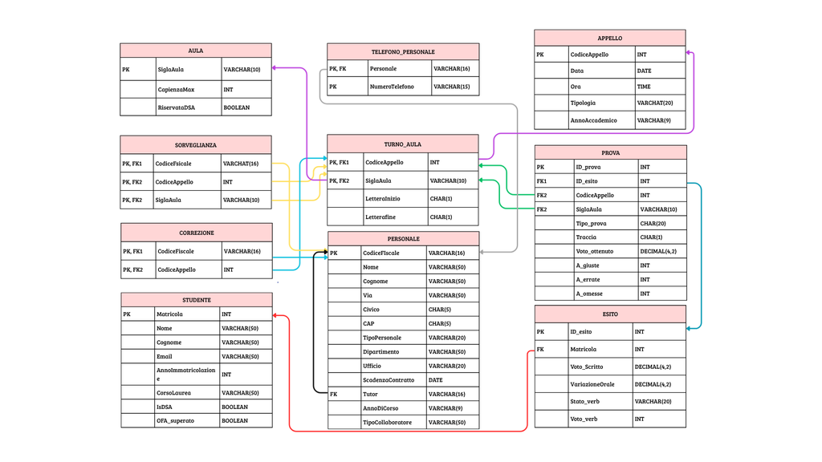

*Clicca sull’immagine per aprirla a schermo intero*

## 4. Implementazione database in PostgreSQL

### 4.1 Perchè PostgreSQL?

SCELTA DEL SERVER

La scelta è ricaduta su PostgreSQL per la sua stretta aderenza agli standard SQL (ANSI) e per l’efficiente gestione dei vincoli di integrità referenziale e di dominio. Queste caratteristiche consentono di verificare la correttezza dello schema logico direttamente a livello di DBMS, minimizzando il rischio di incongruenze nei dati..

A livello pratico, abbiamo organizzato il nostro lavoro utilizzando tre strumenti complementari:

1. **Il Motore del Database:** Il server locale PostgreSQL, che lavora “dietro le quinte” per gestire i dati e verificare che non vengano violati i vincoli imposti.
2. **L’Interfaccia Grafica (GUI):** Per tradurre il progetto in codice (DDL), inserire i dati (DML) e fare i primi test, abbiamo utilizzato **pgAdmin 4**. Lavorare direttamente su questo client ci ha permesso di avere il pieno controllo sulle tabelle e sugli errori durante la fase di sviluppo.
3. **Il Report:** Infine, per presentare il progetto in modo chiaro, abbiamo collegato il database a **RStudio** (sfruttando le librerie `DBI` e `RPostgres`). Questo ci ha consentito di inserire le query SQL direttamente in questo documento R Markdown, generando una relazione finale elegante, navigabile e connessa in tempo reale ai nostri dati.

### 4.2 Scelte per la traduzione dello schema logico in DDL

STRUTTURA E VINCOLI: *Dallo schema logico al DDL*

Al fine di garantire la coerenza dei dati e prevenire anomalie di inserimento, aggiornamento e cancellazione, sono state implementate diverse categorie di vincoli d’integrità:

- **Integrità d’Entità e Referenziale:** Utilizzo sistematico di **PRIMARY KEY** per identificare univocamente le tuple e di **FOREIGN KEY** per mappare le associazioni tra tabelle. Dove logicamente coerente, sono state impostate politiche di reazione come

  ```
  ON DELETE
  CASCADE
  ```

  ```
  PRIMARY KEY
  (Codice_Appello, Sigla_Aula)
  ```

  ```
  DEFAULT
  FALSE
  ```

  e `DEFAULT TRUE`.

### 4.3 Popolamento (DML)

IL POPOLAMENTO DEI DATI (DML): *Simulazione realistica e rispetto dell’integrità referenziale*

L’inserimento dei dati (Data Manipulation Language) non è avvenuto in modo casuale, ma ha seguito un rigido approccio *top-down* per rispettare i vincoli di chiave esterna (`FOREIGN KEY`). Abbiamo prima popolato le entità “forti” e indipendenti (`AULE`, `PERSONALE`, `STUDENTE`), per poi passare alle entità “deboli” o di associazione (`APPELLI`,`TURNO_AULA`,`SORVEGLIANZA`,`ESITO` e `PROVA`).

Al fine di testare il sistema su scenari verosimili, i dati inseriti simulano diverse casistiche reali:

- **Eterogeneità:** Abbiamo inserito un campione di 100 studenti, includendo casistiche particolari come studenti con OFA pendenti e studenti con certificazione DSA.
- **Bocciati agli esami:** Abbiamo simulato i risultati di 7 appelli. Nel nostro inserimento, gli studenti “Respinti” o “Ritirati” in una sessione (es. Gennaio) si ripresentano coerentemente nella sessione successiva (es. Febbraio).
- **Automazione tramite UPDATE:** Per popolare la tabella `ESITO`, anziché inserire i voti a mano, abbiamo sfruttato la potenza di SQL. Abbiamo calcolato la sufficienza della “Parte A”, generato la “Parte B” solo per gli ammessi, e infine utilizzato dei comandi `UPDATE` per far sommare in automatico al database il voto scritto con un’eventuale variazione orale, calcolando così il voto verbale definitivo e lo stato accademico.

### 4.4 Le viste

LE VISTE LOGICHE (VIEW)

Nel nostro progetto abbiamo ritenuto concettualmente errato creare tabelle fisiche ridondanti o “una vista per ogni appello”. Abbiamo invece progettato delle **Viste Logiche Generali** (`CREATE VIEW`). Le Viste sono tabelle virtuali che mascherano la complessità dei `JOIN` sottostanti, offrendo agli utenti finali (es. Segreteria, Docenti) solo i dati di cui hanno bisogno, aumentando così sia l’usabilità che la sicurezza del database.

Nello specifico, abbiamo implementato tre viste principali:

**1. VISTA_TABELLONE_ESITI:** Simula la bacheca universitaria. Unisce i dati dello studente, dell’appello e l’esito finale, permettendo al docente di pubblicare i voti in modo rapido e aggregato.

```sql
CREATE OR REPLACE VIEW vista_tabellone_esiti AS
SELECT DISTINCT
    A.Data_Esame, A.Tipologia AS Sessione,
    S.Matricola, S.Cognome, S.Nome,
    E.Stato_verb AS Esito_Finale, E.Voto_verb AS Voto_Registrato
FROM ESITO E
JOIN STUDENTE S ON E.Matricola = S.Matricola
JOIN PROVA P ON E.ID_esito = P.ID_esito
JOIN APPELLO A ON P.CodiceAppello = A.Codice_Appello
ORDER BY A.Data_Esame DESC, S.Cognome, S.Nome;
```

**2. VISTA_ASSEGNAZIONE_AULE:** Strumento logistico per la Segreteria. Estrae l’elenco degli iscritti per appello mostrando l’aula assegnata (garantendo l’evidenza del flag DSA per i controlli incrociati).

```sql
CREATE OR REPLACE VIEW vista_assegnazione_aule AS
SELECT DISTINCT
A.Data_Esame, A.Tipologia,
S.Matricola, S.Cognome, S.Nome, S.IsDSA,
T.Sigla_Aula AS Aula_Assegnata
FROM STUDENTE S
JOIN ESITO E ON S.Matricola = E.Matricola
JOIN PROVA P ON E.ID_esito = P.ID_esito AND P.Tipo_prova = 'Parte A'
JOIN TURNO_AULA T ON P.CodiceAppello = T.Codice_Appello AND P.SiglaAula = T.Sigla_Aula
JOIN APPELLO A ON T.Codice_Appello = A.Codice_Appello
ORDER BY A.Data_Esame, T.Sigla_Aula, S.Cognome;
```

**3. VISTA_STATISTICHE_APPELLI:** Strumento analitico per la direzione didattica. Aggrega i dati per appello e per stato (Verbalizzato, Respinto, ecc.), fornendo in un’unica griglia il numero di studenti coinvolti e le relative medie di profitto.

```sql
CREATE OR REPLACE VIEW vista_statistiche_appelli AS
SELECT
A.Codice_Appello, A.Data_Esame, A.Tipologia,
E.Stato_verb AS Esito_Appello,
COUNT(E.ID_esito) AS Numero_Studenti,
ROUND(AVG(E.Voto_verb), 2) AS Media_Voti
FROM APPELLO A
JOIN PROVA P ON A.Codice_Appello = P.CodiceAppello
JOIN ESITO E ON P.ID_esito = E.ID_esito
WHERE P.Tipo_prova = 'Parte A'
GROUP BY A.Codice_Appello, A.Data_Esame, A.Tipologia, E.Stato_verb
ORDER BY A.Data_Esame, E.Stato_verb;
```

## 5. Esplorazione del Database

Per permettere un’esplorazione pulita e interattiva del database, abbiamo strutturato questa sezione come una dashboard a comparsa. Clicca sui pannelli sottostanti per visualizzare le tabelle e le viste

### Tabelle

**Visualizza la Tabella STUDENTI**

*Elenco di tutti gli studenti immatricolati, comprensivo di flag per OFA e DSA.*

| matricola | nome | cognome | email | corsolaurea | annoimmatricolazione | ofa_superati | isdsa |
| --- | --- | --- | --- | --- | --- | --- | --- |
| 10085 | Siro | Aosi | siro.aosi@studenti.it | Ingegneria Informatica | 2022 | FALSE | TRUE |
| 10014 | Martina | Barbieri | martina.barb@studenti.it | Ingegneria Gestionale | 2023 | TRUE | FALSE |
| 10065 | Walter | Basso | walter.basso@studenti.it | Ingegneria Edile | 2023 | TRUE | FALSE |
| 10040 | Noemi | Benedetti | noemi.bene@studenti.it | Ingegneria Informatica | 2023 | TRUE | FALSE |
| 10050 | Gaia | Berardi | gaia.ber@studenti.it | Ingegneria Informatica | 2022 | TRUE | FALSE |
| 10002 | Luca | Bianchi | luca.bianchi@studenti.it | Ingegneria Meccanica | 2023 | TRUE | FALSE |
| 10041 | Filippo | Boni | fil.boni@studenti.it | Ingegneria Gestionale | 2023 | TRUE | TRUE |
| 10086 | Tina | Bosi | tina.bosi@studenti.it | Ingegneria Gestionale | 2023 | TRUE | FALSE |
| 10012 | Chiara | Bruno | chiara.bruno@studenti.it | Ingegneria Meccanica | 2023 | TRUE | FALSE |
| 10019 | Stefano | Caruso | stefano.car@studenti.it | Ingegneria Gestionale | 2023 | TRUE | FALSE |

[output cut: 90 more lines]

**Visualizza la Tabella PERSONALE (Docenti UniBg)**

*La commissione d’esame ufficiale, tratta dai registri del Dipartimento di Ingegneria.*

| codicefiscale | nome | cognome | via | civico | cap | tipo_personale | dipartimento | ufficio | scadenza_contratto | tutor | annodicorso | tipocollaboratore |
| --- | --- | --- | --- | --- | --- | --- | --- | --- | --- | --- | --- | --- |
| BNCGNN95T02B157X | Giovanni | Bianchi | Via Baioni | 10 | 24123 | Collaboratore | NA | NA | 2025-12-31 | RMNDND75A01L219K | 3 Anno | 150 Ore |
| GRNLOC70S20Z110W | Loic | Grenie | Viale Marconi | 5 | 24044 | Docente | DIGIP | Ufficio 2.12 |  | NA | NA | NA |
| PDRMRC65M15B157J | Marco | Pedroni | Viale Marconi | 5 | 24044 | Docente | DIGIP | Ufficio 2.08 |  | NA | NA | NA |
| RMNDND75A01L219K | Andrea | Raimondo | Viale Marconi | 5 | 24044 | Docente | DIGIP | Ufficio 2.05 |  | NA | NA | NA |
| RSSMRT98P10L219Y | Marta | Rossi | Via Papa Giovanni | 22 | 24121 | Collaboratore | NA | NA | 2026-06-30 | PDRMRC65M15B157J | LM | Tutorato |
| VRLVLR96S20B157W | Valerio | Verli | Via Stezzano | 5 | 24044 | Collaboratore | NA | NA | 2025-09-15 | GRNLOC70S20Z110W | Dottorato | Didattica |

**Visualizza la Tabella TELEFONO_PERSONALE**

*Numeri di Telefono, ovviamente, un po’ inventati per ogni membro del personale*

| personale | numerotelefono |
| --- | --- |
| RMNDND75A01L219K | 0352052320 |
| PDRMRC65M15B157J | 0352052321 |
| GRNLOC70S20Z110W | 0352052322 |
| BNCGNN95T02B157X | 3334445556 |
| RSSMRT98P10L219Y | 3381112223 |
| VRLVLR96S20B157W | 3479998887 |

**Visualizza la Tabella AULE (Polo di Dalmine)**

*Mappatura delle aule utilizzate per gli esami, ordinate per capienza.*

| sigla_aula | capienza_max | riservata_dsa |
| --- | --- | --- |
| D001 | 250 | FALSE |
| D002 | 250 | FALSE |
| A001 | 180 | FALSE |
| A002 | 180 | FALSE |
| A201 | 72 | TRUE |
| A202 | 72 | FALSE |
| A203 | 72 | FALSE |
| A204 | 72 | TRUE |

**Visualizza la Tabella APPELLI (Calendario 25/26)**

*Estrazione delle date estratte dal PDF ufficiale dell’Anno Accademico in corso.*

| codice_appello | tipologia | data | ora_inizio |
| --- | --- | --- | --- |
| 202501 | Esame Totale | 15/01/2026 | 09:00:00 |
| 202502 | Esame Totale | 12/02/2026 | 09:00:00 |
| 202503 | Primo Parziale | 15/04/2026 | 14:30:00 |
| 202504 | Secondo Parziale | 24/06/2026 | 14:00:00 |
| 202505 | Esame Totale | 24/06/2026 | 14:00:00 |
| 202506 | Esame Totale | 15/07/2026 | 14:00:00 |
| 202507 | Esame Totale | 08/09/2026 | 14:00:00 |

**Visualizza la Tabella TURNO_AULA**

*Assegnazione Aule per ogni appello*

| codice_appello | sigla_aula | letterainizio | letterafine |
| --- | --- | --- | --- |
| 202501 | D001 | A | L |
| 202501 | D002 | M | Z |
| 202501 | A201 | A | Z |
| 202502 | D001 | A | L |
| 202502 | D002 | M | Z |
| 202502 | A201 | A | Z |
| 202505 | D001 | A | L |
| 202505 | D002 | M | Z |
| 202505 | A201 | A | Z |
| 202506 | D001 | A | L |

[output cut: 9 more lines]

**Visualizza la tabella SORVEGLIANZA**

*Assegnazione per ogni appello personale per sorveglianza*

| codicefiscale | codice_appello | sigla_aula |
| --- | --- | --- |
| RMNDND75A01L219K | 202501 | D001 |
| BNCGNN95T02B157X | 202501 | D001 |
| PDRMRC65M15B157J | 202501 | D002 |
| RSSMRT98P10L219Y | 202501 | D002 |
| GRNLOC70S20Z110W | 202501 | A201 |
| PDRMRC65M15B157J | 202502 | D001 |
| GRNLOC70S20Z110W | 202502 | D002 |
| RMNDND75A01L219K | 202502 | A201 |
| VRLVLR96S20B157W | 202502 | A201 |
| BNCGNN95T02B157X | 202503 | A201 |

[output cut: 17 more lines]

**Visualizza la tabella ESITO**

*Esiti degli studenti delle prove*

| id_esito | matricola | voto_scritto | variazioneorale | stato_verb | voto_verb |
| --- | --- | --- | --- | --- | --- |
| 14 | 10014 | NA | NA | Ritirato | NA |
| 25 | 10025 | NA | NA | Assente | NA |
| 55 | 10045 | NA | NA | Ritirato | NA |
| 89 | 10079 | NA | NA | Ritirato | NA |
| 145 | 10095 | NA | NA | Assente | NA |
| 2 | 10002 | NA | NA | Respinto | NA |
| 5 | 10005 | NA | NA | Respinto | NA |
| 9 | 10009 | NA | NA | Respinto | NA |
| 18 | 10018 | NA | NA | Respinto | NA |
| 21 | 10021 | NA | NA | Respinto | NA |

[output cut: 200 more lines]

**Visualizza la tabella PROVA**

*Prove scritte*

| id_prova | id_esito | codiceappello | siglaaula | tipo_prova | traccia | voto_ottenuto | a_giuste | a_errate | a_omesse |
| --- | --- | --- | --- | --- | --- | --- | --- | --- | --- |
| 1 | 1 | 202501 | D001 | Parte A | A | 7.75 | 8 | 1 | 1 |
| 2 | 2 | 202501 | D002 | Parte A | B | 2.75 | 4 | 5 | 1 |
| 3 | 3 | 202501 | A201 | Parte A | C | 5.50 | 6 | 2 | 2 |
| 4 | 4 | 202501 | D001 | Parte A | A | 6.50 | 7 | 2 | 1 |
| 5 | 5 | 202501 | D002 | Parte A | B | 1.25 | 3 | 7 | 0 |
| 6 | 6 | 202501 | D001 | Parte A | C | 10.00 | 10 | 0 | 0 |
| 7 | 7 | 202501 | D002 | Parte A | A | 8.00 | 8 | 0 | 2 |
| 8 | 8 | 202501 | A201 | Parte A | B | 7.50 | 8 | 2 | 0 |
| 9 | 9 | 202501 | D001 | Parte A | C | 3.50 | 4 | 2 | 4 |
| 10 | 10 | 202501 | D002 | Parte A | A | 5.50 | 6 | 2 | 2 |

[output cut: 357 more lines]

**Visualizza la tabella CORREZIONE**

*In questa tabella vengono assegnate le correzioni delle prove di determinati appelli a membri del personale*

| codicefiscale | codiceappello |
| --- | --- |
| RMNDND75A01L219K | 202501 |
| PDRMRC65M15B157J | 202501 |
| GRNLOC70S20Z110W | 202501 |
| RMNDND75A01L219K | 202502 |
| PDRMRC65M15B157J | 202502 |
| VRLVLR96S20B157W | 202502 |
| PDRMRC65M15B157J | 202503 |
| GRNLOC70S20Z110W | 202503 |
| BNCGNN95T02B157X | 202503 |
| RMNDND75A01L219K | 202504 |

[output cut: 10 more lines]

### Viste

**Visualizza la vista TABELLONE ESITI**

| data_esame | sessione | matricola | cognome | nome | esito_finale | voto_registrato |
| --- | --- | --- | --- | --- | --- | --- |
| 2026-09-08 | Esame Totale | 10040 | Benedetti | Noemi | Verbalizzato | 30 |
| 2026-09-08 | Esame Totale | 10041 | Boni | Filippo | Verbalizzato | 25 |
| 2026-09-08 | Esame Totale | 10012 | Bruno | Chiara | Verbalizzato | 25 |
| 2026-09-08 | Esame Totale | 10019 | Caruso | Stefano | Verbalizzato | 26 |
| 2026-09-08 | Esame Totale | 10009 | Conti | Roberto | Respinto | NA |
| 2026-09-08 | Esame Totale | 10067 | Dati | Angelo | Verbalizzato | 26 |
| 2026-09-08 | Esame Totale | 10044 | De Luca | Sonia | Verbalizzato | 28 |
| 2026-09-08 | Esame Totale | 10088 | Dosi | Vera | Verbalizzato | 29 |
| 2026-09-08 | Esame Totale | 10037 | Fabbri | Giacomo | Verbalizzato | 23 |
| 2026-09-08 | Esame Totale | 10020 | Ferrara | Giorgia | Verbalizzato | 31 |

[output cut: 200 more lines]

**Visualizza la vista ASSEGNAZIONE AULE**

| data_esame | tipologia | matricola | cognome | nome | isdsa | aula_assegnata |
| --- | --- | --- | --- | --- | --- | --- |
| 2026-01-15 | Esame Totale | 10029 | Farina | Daniele | TRUE | A201 |
| 2026-01-15 | Esame Totale | 10015 | Fontana | Simone | TRUE | A201 |
| 2026-01-15 | Esame Totale | 10008 | Gallo | Elena | TRUE | A201 |
| 2026-01-15 | Esame Totale | 10022 | Martini | Sofia | TRUE | A201 |
| 2026-01-15 | Esame Totale | 10003 | Verdi | Anna | TRUE | A201 |
| 2026-01-15 | Esame Totale | 10009 | Conti | Roberto | FALSE | D001 |
| 2026-01-15 | Esame Totale | 10030 | D'Amico | Manuela | FALSE | D001 |
| 2026-01-15 | Esame Totale | 10006 | Esposito | Francesca | FALSE | D001 |
| 2026-01-15 | Esame Totale | 10020 | Ferrara | Giorgia | FALSE | D001 |
| 2026-01-15 | Esame Totale | 10025 | Gentile | Riccardo | FALSE | D001 |

[output cut: 200 more lines]

**Visualizza la vista STATISTISCHE APPELLI**

| codice_appello | data_esame | tipologia | esito_appello | numero_studenti | media_voti |
| --- | --- | --- | --- | --- | --- |
| 202501 | 2026-01-15 | Esame Totale | Assente | 1 | NA |
| 202501 | 2026-01-15 | Esame Totale | Respinto | 8 | NA |
| 202501 | 2026-01-15 | Esame Totale | Ritirato | 1 | NA |
| 202501 | 2026-01-15 | Esame Totale | Verbalizzato | 20 | 26.95 |
| 202502 | 2026-02-12 | Esame Totale | Respinto | 9 | NA |
| 202502 | 2026-02-12 | Esame Totale | Ritirato | 1 | NA |
| 202502 | 2026-02-12 | Esame Totale | Verbalizzato | 20 | 26.80 |
| 202503 | 2026-04-15 | Primo Parziale | Respinto | 6 | NA |
| 202503 | 2026-04-15 | Primo Parziale | Ritirato | 1 | NA |
| 202503 | 2026-04-15 | Primo Parziale | Verbalizzato | 23 | 27.09 |

[output cut: 9 more lines]

## 7. Interrogazioni (Query)

### Query 1: Aule assegnate per l’appello di Febbraio

Questa query serve a fornire alla segreteria e agli studenti l’assegnazione delle aule per l’appello di febbraio. Anzichè ricostruire le `JOIN` , abbiamo fatto uso di una `VIEW` costruita precedentemente, durante la fase di implementazione. Per il filtraggio usa la funzione `EXTRACT(MONTH from data_esame)` per isolare il mese di Febbraio, in questo modo abbiamo reso la query riutilizzabile e indipendente dalla data esatta dell’esame. Per motivi di privacy, la query non restituisce l’attributo isdsa ma solo il cognome, nome, matricola dello studente e l’aula assegnata.

```sql
SELECT data_esame, matricola, cognome, nome, aula_assegnata
FROM vista_assegnazione_aule
WHERE EXTRACT(MONTH FROM data_esame)=2
ORDER BY aula_assegnata, cognome
```

| data_esame | matricola | cognome | nome | aula_assegnata |
| --- | --- | --- | --- | --- |
| 2026-02-12 | 10041 | Boni | Filippo | A201 |
| 2026-02-12 | 10049 | Donati | Pietro | A201 |
| 2026-02-12 | 10029 | Farina | Daniele | A201 |
| 2026-02-12 | 10035 | Vitali | Nicola | A201 |
| 2026-02-12 | 10002 | Bianchi | Luca | D001 |
| 2026-02-12 | 10009 | Conti | Roberto | D001 |
| 2026-02-12 | 10030 | D'Amico | Manuela | D001 |
| 2026-02-12 | 10044 | De Luca | Sonia | D001 |
| 2026-02-12 | 10037 | Fabbri | Giacomo | D001 |
| 2026-02-12 | 10025 | Gentile | Riccardo | D001 |

[output cut: 20 more lines]

### Query 2: Controllo aule riservate ai DSA

Questa query serve ad effettuare un controllo sulle aule assegnate, durante gli appelli, agli studenti DSA per vedere se ci sono stati errori nell’assegnazione. Utilizziamo anche qui la vista precedentemente creata per l’assegnazione delle aule (`vista_assegnazione_aule`).

```sql
SELECT
    V.Matricola,
    V.Cognome,
    V.Aula_Assegnata
FROM vista_assegnazione_aule V
JOIN AULA AU ON V.Aula_Assegnata = AU.Sigla_Aula
WHERE V.IsDSA = TRUE AND AU.Riservata_DSA = FALSE;
```

| matricola | cognome | aula_assegnata |
| --- | --- | --- |

In questo caso non abbiamo righe in quanto non ci sono stati errori.

### Query 3: Controllo Calcolo Voto Parte A

Questa query serve ad effettuare un controllo aggiuntivo sul voto della Parte A che viene inserito manualmente. Implementa la formula matematica della prova (1 punto per risposta esatta e -0.25 per errore) e affianca il risultato calcolato in tempo reale al campo `Voto_ottenuto` salvato staticamente nel database.

In sostanza, serve ad assicurare l’assoluta **integrità dei dati**

```sql
SELECT
    PR.ID_prova,
    PR.ID_esito,
    (PR.A_giuste - (PR.A_errate * 0.25)) AS voto_calcolato_tecnico, voto_ottenuto AS voto_registrato
FROM
    PROVA PR
```

| id_prova | id_esito | voto_calcolato_tecnico | voto_registrato |
| --- | --- | --- | --- |
| 1 | 1 | 7.75 | 7.75 |
| 2 | 2 | 2.75 | 2.75 |
| 3 | 3 | 5.50 | 5.50 |
| 4 | 4 | 6.50 | 6.50 |
| 5 | 5 | 1.25 | 1.25 |
| 6 | 6 | 10.00 | 10.00 |
| 7 | 7 | 8.00 | 8.00 |
| 8 | 8 | 7.50 | 7.50 |
| 9 | 9 | 3.50 | 3.50 |
| 10 | 10 | 5.50 | 5.50 |

[output cut: 357 more lines]

### Query 4: Tutor collaboratori

Questa query richiede di associare ogni collaboratore/tutor al suo docente strutturato di riferimento.

```sql
SELECT
    C.Nome AS collaboratore,
    C.Cognome,
    T.Nome AS nome_tutor,
    T.Cognome AS cognome_tutor
FROM
    PERSONALE C
JOIN
    PERSONALE T ON C.Tutor = T.CodiceFiscale
WHERE
    C.TipoCollaboratore IS NOT NULL;
```

| collaboratore | cognome | nome_tutor | cognome_tutor |
| --- | --- | --- | --- |
| Giovanni | Bianchi | Andrea | Raimondo |
| Marta | Rossi | Marco | Pedroni |
| Valerio | Verli | Loic | Grenie |

### Query 5: Elenco personale addetto alla sorveglianza nelle aule durante gli esami

Questa query richiede di produrre come risultato l’elenco del personale che deve fare sorveglianza nelle aule durante gli esami ed ordinarlo per codice appello, per rendere tutto più leggibile

```sql
SELECT
    S.Codice_Appello,
    S.Sigla_Aula,
    P.Cognome,
    P.Nome
FROM
    SORVEGLIANZA S
JOIN
    PERSONALE P ON S.CodiceFiscale = P.CodiceFiscale
ORDER BY
    S.Codice_Appello
```

| codice_appello | sigla_aula | cognome | nome |
| --- | --- | --- | --- |
| 202501 | D001 | Raimondo | Andrea |
| 202501 | D001 | Bianchi | Giovanni |
| 202501 | D002 | Pedroni | Marco |
| 202501 | D002 | Rossi | Marta |
| 202501 | A201 | Grenie | Loic |
| 202502 | D002 | Grenie | Loic |
| 202502 | D001 | Pedroni | Marco |
| 202502 | A201 | Raimondo | Andrea |
| 202502 | A201 | Verli | Valerio |
| 202503 | A201 | Bianchi | Giovanni |

[output cut: 17 more lines]

### Query 6: Studenti non in regola con gli OFA

Questa query trova gli studenti che hanno preso un voto sufficiente (>=18) ma che hanno ancora gli OFA pendenti, quindi teoricamente non potremmo verbalizzare il voto. Restituisce la matricola, il cognome e il voto “in sospeso”.

```sql
SELECT
    S.Matricola,
    S.Cognome,
    E.Voto_verb
FROM
    STUDENTE S
JOIN
    ESITO E ON S.Matricola = E.Matricola
WHERE
    S.OFA_superati = FALSE
    AND E.Voto_verb >= 18
```

| matricola | cognome | voto_verb |
| --- | --- | --- |
| 10017 | Mariani | 29 |
| 10077 | Pini | 24 |
| 10058 | Parodi | 29 |
| 10085 | Aosi | 30 |
| 10067 | Dati | 26 |
| 10035 | Vitali | 25 |
| 10046 | Pagano | 27 |
| 10004 | Rizzo | 27 |
| 10026 | Pellegrini | 26 |
| 10096 | Nosi | 27 |

[output cut: 7 more lines]

### Query 7: Assegnazione correzioni prove al personale

Questa query serve a tracciare quali professori di ruolo (strutturati) si sono occupati delle correzioni. Escludiamo i collaboratori controllando che il dipartimento non sia null.

```sql
SELECT
    P.Cognome,
    P.Nome,
    A.Tipologia,
    A.Data_esame
FROM
    CORREZIONE C
JOIN
    PERSONALE P ON C.CodiceFiscale = P.CodiceFiscale
JOIN
    APPELLO A ON C.CodiceAppello = A.Codice_Appello
WHERE
    P.Dipartimento IS NOT NULL
```

| cognome | nome | tipologia | data_esame |
| --- | --- | --- | --- |
| Raimondo | Andrea | Esame Totale | 2026-01-15 |
| Pedroni | Marco | Esame Totale | 2026-01-15 |
| Grenie | Loic | Esame Totale | 2026-01-15 |
| Raimondo | Andrea | Esame Totale | 2026-02-12 |
| Pedroni | Marco | Esame Totale | 2026-02-12 |
| Pedroni | Marco | Primo Parziale | 2026-04-15 |
| Grenie | Loic | Primo Parziale | 2026-04-15 |
| Raimondo | Andrea | Secondo Parziale | 2026-06-24 |
| Grenie | Loic | Secondo Parziale | 2026-06-24 |
| Raimondo | Andrea | Esame Totale | 2026-06-24 |

[output cut: 7 more lines]

### Query 8: Statistica Affollamento aule

Questa qeur ha come obbiettivo monitorare l’affluenza reale per ogni singola data d’esame rispetto alla capacità logistica delle aule. Riutilizzando il codice, questa query interroga la `vista_assegnazione_aule` unendola all’anagrafica `AULA`. Raggruppando per data e aula, conta i posti occupati (tramite la matricola) e calcola dinamicamente il tasso di saturazione (`Posti Occupati / Capienza Massima * 100`).

```sql
SELECT
    V.Data_Esame,
    V.Aula_Assegnata,
    AU.Capienza_Max,
    COUNT(V.Matricola) AS Posti_Occupati,
    ROUND((COUNT(V.Matricola) * 100.0) / AU.Capienza_Max, 2) AS Tasso_Saturazione_Perc
FROM vista_assegnazione_aule V
JOIN AULA AU ON V.Aula_Assegnata = AU.Sigla_Aula
GROUP BY V.Data_Esame, V.Aula_Assegnata, AU.Capienza_Max
ORDER BY V.Data_Esame, V.Aula_Assegnata;
```

| data_esame | aula_assegnata | capienza_max | posti_occupati | tasso_saturazione_perc |
| --- | --- | --- | --- | --- |
| 2026-01-15 | A201 | 72 | 5 | 6.94 |
| 2026-01-15 | D001 | 250 | 13 | 5.20 |
| 2026-01-15 | D002 | 250 | 12 | 4.80 |
| 2026-02-12 | A201 | 72 | 4 | 5.56 |
| 2026-02-12 | D001 | 250 | 13 | 5.20 |
| 2026-02-12 | D002 | 250 | 13 | 5.20 |
| 2026-04-15 | A201 | 72 | 4 | 5.56 |
| 2026-04-15 | A202 | 72 | 26 | 36.11 |
| 2026-06-24 | A201 | 72 | 9 | 12.50 |
| 2026-06-24 | A202 | 72 | 26 | 36.11 |

[output cut: 8 more lines]

Questa statistica fornisce alla logistica d’ateneo un indicatore percentuale chiaro per ottimizzare le risorse. Permette di evidenziare immediatamente se si stanno sprecando aule gigantesche per pochi iscritti o se, al contrario, ci si sta avvicinando pericolosamente al limite di sicurezza dell’aula.

### Query 9: Rendimento medio per corso di studi

Questa query calcola il rendimento medio degli studenti diviso per corso di studi. Consideriamo solo gli esami che sono già stati effettivamente verbalizzati.

```sql
SELECT
    S.CorsoLaurea,
    AVG(E.Voto_verb) AS media_voto_finale
FROM
    STUDENTE S
JOIN
    ESITO E ON S.Matricola = E.Matricola
WHERE
    E.Stato_verb = 'Verbalizzato'
GROUP BY
    S.CorsoLaurea
```

| corsolaurea | media_voto_finale |
| --- | --- |
| Ingegneria Edile | 27.07407 |
| Ingegneria Informatica | 27.09524 |
| Ingegneria Gestionale | 27.20000 |
| Ingegneria Meccanica | 26.70000 |
| Ingegneria Biomedica | 27.21429 |

### Query 10: Elenco studenti ritirati o respinti

Questa query estrae l’elenco degli studenti che non hanno passato l’esame (bocciati o ritirati). C’è una subquery dentro per collegare correttamente i dati all’appello giusto.

```sql
SELECT
    S.Matricola,
    S.Cognome,
    E.Stato_verb,
    A.Data_esame
FROM
    STUDENTE S
JOIN
    ESITO E ON S.Matricola = E.Matricola
JOIN
    APPELLO A ON E.ID_esito IN (
        SELECT PR.ID_esito
        FROM PROVA PR
        WHERE PR.CodiceAppello = A.Codice_Appello
    )
WHERE
    E.Stato_verb IN ('Respinto', 'Ritirato')
```

| matricola | cognome | stato_verb | data_esame |
| --- | --- | --- | --- |
| 10027 | Moretti | Respinto | 2026-01-15 |
| 10045 | Pellegrini | Ritirato | 2026-02-12 |
| 10049 | Donati | Respinto | 2026-02-12 |
| 10029 | Farina | Respinto | 2026-02-12 |
| 10032 | Piras | Respinto | 2026-02-12 |
| 10005 | Ferrari | Respinto | 2026-01-15 |
| 10049 | Donati | Respinto | 2026-06-24 |
| 10080 | Sosi | Respinto | 2026-04-15 |
| 10099 | Quosi | Respinto | 2026-06-24 |
| 10021 | Galli | Respinto | 2026-01-15 |

[output cut: 41 more lines]